# Boom Bike Sharing

## Problem Statement

A bike-sharing system is a service in which bikes are made available for shared use to individuals on a short term basis for a price or free. Many bike share systems allow people to borrow a bike from a "dock" which is usually computer-controlled wherein the user enters the payment information, and the system unlocks it. This bike can then be returned to another dock belonging to the same system.

A US bike-sharing provider BoomBikes has recently suffered considerable dips in their revenues due to the ongoing Corona pandemic. The company is finding it v ry difficult to sustain in the current market scenario. So, it has decided to co me up with a mindful business plan to be able to accelerate its revenue as soon as the ongoing lockdown comes to an end, and the economy restores to a healthy state.

In such an attempt, BoomBikes aspires to understand the demand for shared bikes among the people after this ongoing quarantine situation ends across the ation due to Covid-19. They have planned this to prepare themselves to cater o the people's needs once the situation gets better all around and stand out from other service providers and make huge profits.

They have contracted a consulting company to understand the factors on w hich the demand for these shared bikes depends. Specifically, they want to unders tand the factors affecting the demand for these shared bikes in the American market. The company wants

- Which variables are significant in predicting the demand for shared bikes.
- How well those variables describe the bike demands

Based on various meteorological surveys and people's styles, the service provider firm has gathered a large dataset on daily bike demands across the American market based on some factors.

## Business Goal

the company want to model the demand for shared bikes with the available independent variables. It will be used by the management to understand how exactly the demands vary with different features. They can accordingly manipulate the business strategy to meet the demand levels and meet the customer's expectations. Further, the model will be a good way for management to understand the demand dynamics of a new market.

## Table of content

1. Reading and Understanding Data
   - Data Quality Check
   - Visualising the Data
   - Checking correlation between numerical variables
   - Visulization on numerical columns
   - Handlig Outliers for numerical columns
   - Visulization onn categorical variable
   - Handling Outliers for categorical variable
2. Data Preparation
   - Creating Dummy Variables
   - Splitting data into train and test
   - Rescaling Variables
3. Training The Model
   - Model 1
   - Recursive Feature Elimination
   - Model 2 : Using RFE
   - Model 3
   - Model 4
   - Model 5
   - Model 6
   - Model 7
   - Model 8
   - Model 9
   - Final Model
4. Residual Analysis of Train-Data
5. Predictions on test Data
6. Conclusion

## Reading and Understanding Data

Lets import numpy and pandas and read the bike sharing data set

```python
# supress Warning
import warnings
warnings.filterwarnings("ignore")
```

```python
# Importing necessarylibraries
import pandas as pd
import numpy as np
```

```python
Bikesharing = pd.read_csv("day.csv")
```

```python
Bikesharing.head()
```

|  | instant | dteday | season | yr | mnth | holiday | weekday | workingday | weathersit | temp | atemp | hum | windspeed | casual | registered | cnt |
| --- | --- | --- | --- | --- | --- | --- | --- | --- | --- | --- | --- | --- | --- | --- | --- | --- |
| 0 | 1 | 01-01-2018 | 1 | 0 | 1 | 0 | 1 | 1 | 2 | 14.110847 | 18.18125 | 80.5833 | 10.749882 | 331 | 654 | 985 |
| 1 | 2 | 02-01-2018 | 1 | 0 | 1 | 0 | 2 | 1 | 2 | 14.902598 | 17.68695 | 69.6087 | 16.652113 | 131 | 670 | 801 |
| 2 | 3 | 03-01-2018 | 1 | 0 | 1 | 0 | 3 | 1 | 1 | 8.050924 | 9.47025 | 43.7273 | 16.636703 | 120 | 1229 | 1349 |
| 3 | 4 | 04-01-2018 | 1 | 0 | 1 | 0 | 4 | 1 | 1 | 8.200000 | 10.60610 | 59.0435 | 10.739832 | 108 | 1454 | 1562 |
| 4 | 5 | 05-01-2018 | 1 | 0 | 1 | 0 | 5 | 1 | 1 | 9.305237 | 11.46350 | 43.6957 | 12.522300 | 82 | 1518 | 1600 |

```python
Bikesharing.shape
```

```
(730, 16)
```

```python
Bikesharing.info()
```

```
<class 'pandas.core.frame.DataFrame'>
RangeIndex: 730 entries, 0 to 729
Data columns (total 16 columns):
 #   Column      Non-Null Count  Dtype
---  ------      --------------  -----
 0   instant     730 non-null    int64
 1   dteday      730 non-null    object
 2   season      730 non-null    int64
 3   yr          730 non-null    int64
 4   mnth        730 non-null    int64
 5   holiday     730 non-null    int64
 6   weekday     730 non-null    int64
 7   workingday  730 non-null    int64
 8   weathersit  730 non-null    int64
 9   temp        730 non-null    float64
 10  atemp       730 non-null    float64
 11  hum         730 non-null    float64
 12  windspeed   730 non-null    float64
 13  casual      730 non-null    int64
 14  registered  730 non-null    int64
 15  cnt         730 non-null    int64
dtypes: float64(4), int64(11), object(1)
memory usage: 91.4+ KB
```

- No missing Values found in data

```python
Bikesharing.describe()
```

|  | instant | season | yr | mnth | holiday | weekday | workingday | weathersit | temp | atemp | hum | windspeed | casual | registered | cnt |
| --- | --- | --- | --- | --- | --- | --- | --- | --- | --- | --- | --- | --- | --- | --- | --- |
| count | 730.000000 | 730.000000 | 730.000000 | 730.000000 | 730.000000 | 730.000000 | 730.000000 | 730.000000 | 730.000000 | 730.000000 | 730.000000 | 730.000000 | 730.000000 | 730.000000 | 730.000000 |
| mean | 365.500000 | 2.498630 | 0.500000 | 6.526027 | 0.028767 | 2.995890 | 0.690411 | 1.394521 | 20.319259 | 23.726322 | 62.765175 | 12.763620 | 849.249315 | 3658.757534 | 4508.006849 |
| std | 210.877136 | 1.110184 | 0.500343 | 3.450215 | 0.167266 | 2.000339 | 0.462641 | 0.544807 | 7.506729 | 8.150308 | 14.237589 | 5.195841 | 686.479875 | 1559.758728 | 1936.011647 |
| min | 1.000000 | 1.000000 | 0.000000 | 1.000000 | 0.000000 | 0.000000 | 0.000000 | 1.000000 | 2.424346 | 3.953480 | 0.000000 | 1.500244 | 2.000000 | 20.000000 | 22.000000 |
| 25% | 183.250000 | 2.000000 | 0.000000 | 4.000000 | 0.000000 | 1.000000 | 0.000000 | 1.000000 | 13.811885 | 16.889713 | 52.000000 | 9.041650 | 316.250000 | 2502.250000 | 3169.750000 |
| 50% | 365.500000 | 3.000000 | 0.500000 | 7.000000 | 0.000000 | 3.000000 | 1.000000 | 1.000000 | 20.465826 | 24.368225 | 62.625000 | 12.125325 | 717.000000 | 3664.500000 | 4548.500000 |
| 75% | 547.750000 | 3.000000 | 1.000000 | 10.000000 | 0.000000 | 5.000000 | 1.000000 | 2.000000 | 26.880615 | 30.445775 | 72.989575 | 15.625589 | 1096.500000 | 4783.250000 | 5966.000000 |
| max | 730.000000 | 4.000000 | 1.000000 | 12.000000 | 1.000000 | 6.000000 | 1.000000 | 3.000000 | 35.328347 | 42.044800 | 97.250000 | 34.000021 | 3410.000000 | 6946.000000 | 8714.000000 |

## Data Quality Check

### Changing some categorical variable for further analysis of data continous and categorical separately

- Deleting some columns casual, registered as both comes under cnt column
  - No need of instant column
  - no need of dteday as month and year is already there for analysis
- changing mnth as month
- changing temp : temperature
- changing hum: humidity

```python
# copying the Bikesharing data set
data = Bikesharing.copy()
```

```python
data.rename(columns={"yr" : "year", "mnth":"month", "temp":"Temperature" ,"hum":"humidity"}, inplace=True)
```

```python
data.head()
```

|  | instant | dteday | season | year | month | holiday | weekday | workingday | weathersit | Temperature | atemp | humidity | windspeed | casual | registered | cnt |
| --- | --- | --- | --- | --- | --- | --- | --- | --- | --- | --- | --- | --- | --- | --- | --- | --- |
| 0 | 1 | 01-01-2018 | 1 | 0 | 1 | 0 | 1 | 1 | 2 | 14.110847 | 18.18125 | 80.5833 | 10.749882 | 331 | 654 | 985 |
| 1 | 2 | 02-01-2018 | 1 | 0 | 1 | 0 | 2 | 1 | 2 | 14.902598 | 17.68695 | 69.6087 | 16.652113 | 131 | 670 | 801 |
| 2 | 3 | 03-01-2018 | 1 | 0 | 1 | 0 | 3 | 1 | 1 | 8.050924 | 9.47025 | 43.7273 | 16.636703 | 120 | 1229 | 1349 |
| 3 | 4 | 04-01-2018 | 1 | 0 | 1 | 0 | 4 | 1 | 1 | 8.200000 | 10.60610 | 59.0435 | 10.739832 | 108 | 1454 | 1562 |
| 4 | 5 | 05-01-2018 | 1 | 0 | 1 | 0 | 5 | 1 | 1 | 9.305237 | 11.46350 | 43.6957 | 12.522300 | 82 | 1518 | 1600 |

```python
drop_columns = ['instant','dteday','casual','registered']
data = data.drop(drop_columns, axis=1)
```

```python
data.head()
```

|  | season | year | month | holiday | weekday | workingday | weathersit | Temperature | atemp | humidity | windspeed | cnt |
| --- | --- | --- | --- | --- | --- | --- | --- | --- | --- | --- | --- | --- |
| 0 | 1 | 0 | 1 | 0 | 1 | 1 | 2 | 14.110847 | 18.18125 | 80.5833 | 10.749882 | 985 |
| 1 | 1 | 0 | 1 | 0 | 2 | 1 | 2 | 14.902598 | 17.68695 | 69.6087 | 16.652113 | 801 |
| 2 | 1 | 0 | 1 | 0 | 3 | 1 | 1 | 8.050924 | 9.47025 | 43.7273 | 16.636703 | 1349 |
| 3 | 1 | 0 | 1 | 0 | 4 | 1 | 1 | 8.200000 | 10.60610 | 59.0435 | 10.739832 | 1562 |
| 4 | 1 | 0 | 1 | 0 | 5 | 1 | 1 | 9.305237 | 11.46350 | 43.6957 | 12.522300 | 1600 |

## Checking correlation between numerical variables

```python
data[['Temperature','atemp','humidity','windspeed']].corr()
```

|  | Temperature | atemp | humidity | windspeed |
| --- | --- | --- | --- | --- |
| Temperature | 1.000000 | 0.991696 | 0.128565 | -0.158186 |
| atemp | 0.991696 | 1.000000 | 0.141512 | -0.183876 |
| humidity | 0.128565 | 0.141512 | 1.000000 | -0.248506 |
| windspeed | -0.158186 | -0.183876 | -0.248506 | 1.000000 |

- A numerical value ranging from -1 to 1, which indicates the strength and direction of the relationship between them , highly correlated to each other.
- As seen `Temperature` and `atemp` is almost 1
- Dropping feature `atemp`

```python
data.drop('atemp', axis =1 ,inplace= True)
```

```python
data['season'].unique()
```

```
array([1, 2, 3, 4], dtype=int64)
```

```python
data['season'] = data['season'].replace({1 : 'spring',
                                         2: 'summer',
                                         3 : 'fall',
                                          4 : 'winter'})
```

```python
data['month'] = data['month'].replace({1 : 'january',
                                       2 : 'february',
                                       3 : 'march',
                                       4 : 'april',
                                       5 : 'may',
                                       6 : 'june',
                                       7 : 'july',
                                       8 : 'august',
                                       9 : 'september',
                                       10 : 'october',
                                      11 : 'november',
                                      12 :'december' })
```

```python
data['weekday'].unique()
```

```
array([1, 2, 3, 4, 5, 6, 0], dtype=int64)
```

```python
data['weekday'] = data['weekday'].replace({0 :'Sunday',
                                           1: 'Monday',
                                           2: 'Tuesday',
                                           3: 'Wednesday',
                                           4: 'Thursday',
                                           5: 'Friday',
                                           6: 'Saturday'})
```

```python
data['weathersit'].unique()
```

```
array([2, 1, 3], dtype=int64)
```

```python
data['weathersit'] = data['weathersit'].replace({1 : 'clear' ,2: 'cloudy' , 3: 'light_rain' , 4: 'heavy_rain'
})
```

## Visualising the Data

Let's now spend some time doing what is arguably the most important step - **understanding the data**.

- If there is some obvious multicollinearity going on, this is the first place to catch it
- Here's where you'll also identify if some predictors directly have a strong association with the outcome variable that is cnt

We'll visualise our data using `matplotlib` and `seaborn`.

```python
data.head()
```

|  | season | year | month | holiday | weekday | workingday | weathersit | Temperature | humidity | windspeed | cnt |
| --- | --- | --- | --- | --- | --- | --- | --- | --- | --- | --- | --- |
| 0 | spring | 0 | january | 0 | Monday | 1 | cloudy | 14.110847 | 80.5833 | 10.749882 | 985 |
| 1 | spring | 0 | january | 0 | Tuesday | 1 | cloudy | 14.902598 | 69.6087 | 16.652113 | 801 |
| 2 | spring | 0 | january | 0 | Wednesday | 1 | clear | 8.050924 | 43.7273 | 16.636703 | 1349 |
| 3 | spring | 0 | january | 0 | Thursday | 1 | clear | 8.200000 | 59.0435 | 10.739832 | 1562 |
| 4 | spring | 0 | january | 0 | Friday | 1 | clear | 9.305237 | 43.6957 | 12.522300 | 1600 |

```python
import matplotlib.pyplot as plt
import seaborn as sns
```

### Visulization on numerical columns

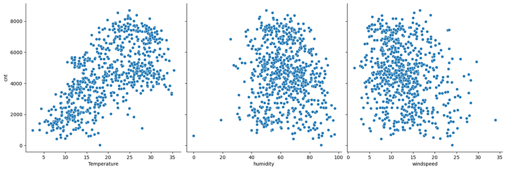

```python
#visulaizing the numerical variable
sns.pairplot(data=data,x_vars=['Temperature','humidity','windspeed'],y_vars='cnt',kind='scatter',height=5,aspect=1);
```

Seeing the scatter plot Found some outliers so will remove outliers by taking reference of scatter plot as I can also see outliers are less in number we can also skip the step for removing an outliers but I have removed the outlier just to get the clean data

### Handlig Outliers for numerical columns

```python
data = data.drop(index = data[(data['Temperature'] > 15) & (data['Temperature'] < 20) & (data['cnt'] < 100)].index)
data = data.drop(index = data[(data['Temperature'] > 25) & (data['Temperature'] < 30) & (data['cnt'] < 2000)].index)

data = data.drop(index = data[(data['humidity'] < 20)].index)

data = data.drop(index = data[(data['windspeed'] > 30)].index)
```

As we can see the humidity and windspeed having outliers no much in values but we can still remove them

```python
data.shape
```

```
(725, 11)
```

### Visulization on categorical columns

For categorical column i have used boxplot for the outlier analysis

```python
cat_col =  data[['holiday','workingday','season','weekday','weathersit','month']]
```

```python
def plotting(data, column):
    fig = plt.figure(figsize=(8,6))

    ax1 = plt.subplot(2,2,1)
    sns.boxplot(data = data, palette='Set1',x = column, y = 'cnt', ax = ax1)
    plt.title('Plotting data for the column: '+ column)
    plt.xticks(rotation=90)

    plt.tight_layout() # Or equivalently,  "plt.tight_layout()"

    plt.show()
```

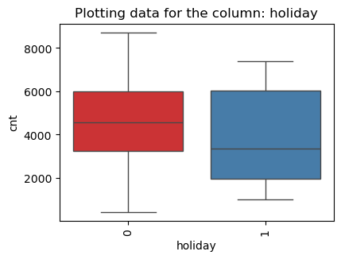

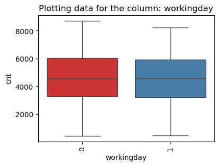

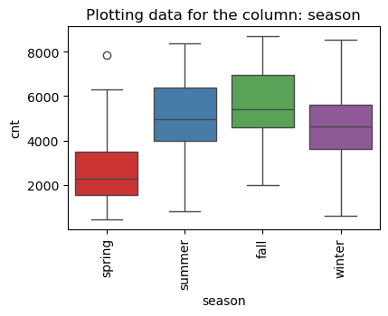

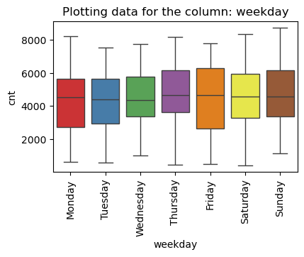

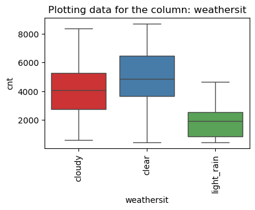

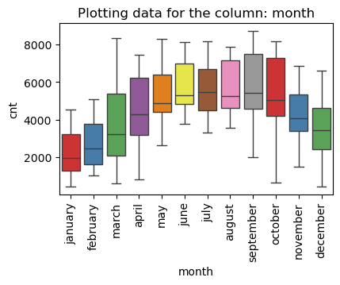

```python
for i in cat_col:
    plotting(data, i)
```

**Working Day and Holiday :**

- Rental counts are generally lower on holidays compared to working days.
- Holidays show greater fluctuations in rental demand.

**Season**

- Fall season has the highest demand.

**Weekday**

- There is no trend found in weekdays

**Weathersit**

- When Weathersit is clear bike demand is high

**Month**

## Handling Outliers for categorical variable

```python
# Dropping outliers in Categorical Variables
data = data.drop(index = data[(data['season'] == 'spring') & (data['cnt'] > 7000)].index)
```

```python
data.shape
```

```
(724, 11)
```

```python
data.head()
```

|  | season | year | month | holiday | weekday | workingday | weathersit | Temperature | humidity | windspeed | cnt |
| --- | --- | --- | --- | --- | --- | --- | --- | --- | --- | --- | --- |
| 0 | spring | 0 | january | 0 | Monday | 1 | cloudy | 14.110847 | 80.5833 | 10.749882 | 985 |
| 1 | spring | 0 | january | 0 | Tuesday | 1 | cloudy | 14.902598 | 69.6087 | 16.652113 | 801 |
| 2 | spring | 0 | january | 0 | Wednesday | 1 | clear | 8.050924 | 43.7273 | 16.636703 | 1349 |
| 3 | spring | 0 | january | 0 | Thursday | 1 | clear | 8.200000 | 59.0435 | 10.739832 | 1562 |
| 4 | spring | 0 | january | 0 | Friday | 1 | clear | 9.305237 | 43.6957 | 12.522300 | 1600 |

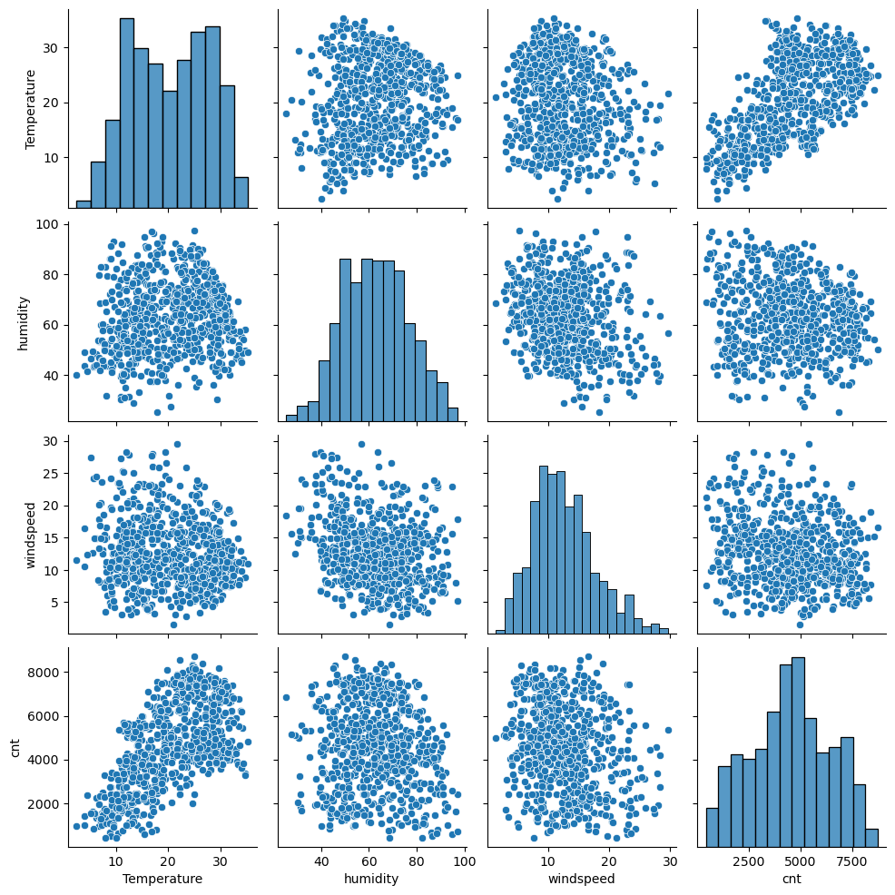

```python
sns.pairplot(data,vars=["Temperature","humidity","windspeed","cnt"])
```

- As I can see `Temperature` as some linear relationahipp with target variable `cnt`
- Lets further analyse using heatmap for numerical variables

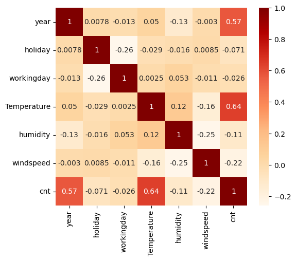

```python
plt.figure(figsize = (6, 5))
sns.heatmap(data.corr(numeric_only = True), annot = True, cmap = 'OrRd')
plt.show()
```

- Here we can see `Temperature` is higly corelated with `cnt` followed by `Year`

## Data Preparation

- Encoding: - Categorical Variables to dummy variables

## Creating Dummy Variables

```python
## creating dummy variable
season_dummies = pd.get_dummies(data['season'] ,dtype= int ,drop_first=True)
month_dummies = pd.get_dummies(data['month'],dtype= int,drop_first=True)
weekday_dummies = pd.get_dummies(data['weekday'],dtype= int,drop_first= True)
weathersit_dummies = pd.get_dummies(data['weathersit'],dtype= int,drop_first= True)
```

```python
# Concat dummy dataframe with original one
data = pd.concat([data, season_dummies,month_dummies,weekday_dummies,weathersit_dummies], axis =1)
data.head()
```

|  | season | year | month | holiday | weekday | workingday | weathersit | Temperature | humidity | windspeed | ... | october | september | Monday | Saturday | Sunday | Thursday | Tuesday | Wednesday | cloudy | light_rain |
| --- | --- | --- | --- | --- | --- | --- | --- | --- | --- | --- | --- | --- | --- | --- | --- | --- | --- | --- | --- | --- | --- |
| 0 | spring | 0 | january | 0 | Monday | 1 | cloudy | 14.110847 | 80.5833 | 10.749882 | ... | 0 | 0 | 1 | 0 | 0 | 0 | 0 | 0 | 1 | 0 |
| 1 | spring | 0 | january | 0 | Tuesday | 1 | cloudy | 14.902598 | 69.6087 | 16.652113 | ... | 0 | 0 | 0 | 0 | 0 | 0 | 1 | 0 | 1 | 0 |
| 2 | spring | 0 | january | 0 | Wednesday | 1 | clear | 8.050924 | 43.7273 | 16.636703 | ... | 0 | 0 | 0 | 0 | 0 | 0 | 0 | 1 | 0 | 0 |
| 3 | spring | 0 | january | 0 | Thursday | 1 | clear | 8.200000 | 59.0435 | 10.739832 | ... | 0 | 0 | 0 | 0 | 0 | 1 | 0 | 0 | 0 | 0 |
| 4 | spring | 0 | january | 0 | Friday | 1 | clear | 9.305237 | 43.6957 | 12.522300 | ... | 0 | 0 | 0 | 0 | 0 | 0 | 0 | 0 | 0 | 0 |

5 rows × 33 columns

```python
# Deleting original variables
data = data.drop(columns=['season','month','weekday','weathersit'] )
```

```python
data.columns
```

```
Index(['year', 'holiday', 'workingday', 'Temperature', 'humidity', 'windspeed',
       'cnt', 'spring', 'summer', 'winter', 'august', 'december', 'february',
       'january', 'july', 'june', 'march', 'may', 'november', 'october',
       'september', 'Monday', 'Saturday', 'Sunday', 'Thursday', 'Tuesday',
       'Wednesday', 'cloudy', 'light_rain'],
      dtype='object')
```

```python
data.shape
```

```
(724, 29)
```

## Splitting data into train and test

```python
from sklearn.model_selection import train_test_split
```

```python
data_train,data_test = train_test_split(data,train_size=0.7,random_state=100)
```

```python
print(data_train.shape)
print(data_test.shape)
```

```
(506, 29)
(218, 29)
```

```python
pd.set_option('display.max_columns',None)
```

```python
data.head()
```

|  | year | holiday | workingday | Temperature | humidity | windspeed | cnt | spring | summer | winter | august | december | february | january | july | june | march | may | november | october | september | Monday | Saturday | Sunday | Thursday | Tuesday | Wednesday | cloudy | light_rain |
| --- | --- | --- | --- | --- | --- | --- | --- | --- | --- | --- | --- | --- | --- | --- | --- | --- | --- | --- | --- | --- | --- | --- | --- | --- | --- | --- | --- | --- | --- |
| 0 | 0 | 0 | 1 | 14.110847 | 80.5833 | 10.749882 | 985 | 1 | 0 | 0 | 0 | 0 | 0 | 1 | 0 | 0 | 0 | 0 | 0 | 0 | 0 | 1 | 0 | 0 | 0 | 0 | 0 | 1 | 0 |
| 1 | 0 | 0 | 1 | 14.902598 | 69.6087 | 16.652113 | 801 | 1 | 0 | 0 | 0 | 0 | 0 | 1 | 0 | 0 | 0 | 0 | 0 | 0 | 0 | 0 | 0 | 0 | 0 | 1 | 0 | 1 | 0 |
| 2 | 0 | 0 | 1 | 8.050924 | 43.7273 | 16.636703 | 1349 | 1 | 0 | 0 | 0 | 0 | 0 | 1 | 0 | 0 | 0 | 0 | 0 | 0 | 0 | 0 | 0 | 0 | 0 | 0 | 1 | 0 | 0 |
| 3 | 0 | 0 | 1 | 8.200000 | 59.0435 | 10.739832 | 1562 | 1 | 0 | 0 | 0 | 0 | 0 | 1 | 0 | 0 | 0 | 0 | 0 | 0 | 0 | 0 | 0 | 0 | 1 | 0 | 0 | 0 | 0 |
| 4 | 0 | 0 | 1 | 9.305237 | 43.6957 | 12.522300 | 1600 | 1 | 0 | 0 | 0 | 0 | 0 | 1 | 0 | 0 | 0 | 0 | 0 | 0 | 0 | 0 | 0 | 0 | 0 | 0 | 0 | 0 | 0 |

```python
data.shape
```

```
(724, 29)
```

## Rescaling variables using MinMax Scaler

```python
from sklearn.preprocessing import MinMaxScaler
```

```python
scaler = MinMaxScaler()

num_vars =  ['Temperature','humidity','windspeed','cnt']

data_train[num_vars]  = scaler.fit_transform(data_train[num_vars] )
data_train.head()
```

|  | year | holiday | workingday | Temperature | humidity | windspeed | cnt | spring | summer | winter | august | december | february | january | july | june | march | may | november | october | september | Monday | Saturday | Sunday | Thursday | Tuesday | Wednesday | cloudy | light_rain |
| --- | --- | --- | --- | --- | --- | --- | --- | --- | --- | --- | --- | --- | --- | --- | --- | --- | --- | --- | --- | --- | --- | --- | --- | --- | --- | --- | --- | --- | --- |
| 422 | 1 | 0 | 1 | 0.383206 | 0.281444 | 0.615256 | 0.469757 | 1 | 0 | 0 | 0 | 0 | 1 | 0 | 0 | 0 | 0 | 0 | 0 | 0 | 0 | 0 | 0 | 0 | 0 | 0 | 1 | 0 | 0 |
| 728 | 1 | 0 | 1 | 0.245101 | 0.270255 | 0.822447 | 0.164795 | 1 | 0 | 0 | 0 | 1 | 0 | 0 | 0 | 0 | 0 | 0 | 0 | 0 | 0 | 1 | 0 | 0 | 0 | 0 | 0 | 0 | 0 |
| 614 | 1 | 0 | 0 | 0.802708 | 0.647560 | 0.373836 | 0.853918 | 0 | 0 | 0 | 0 | 0 | 0 | 0 | 0 | 0 | 0 | 0 | 0 | 0 | 1 | 0 | 1 | 0 | 0 | 0 | 0 | 0 | 0 |
| 113 | 0 | 0 | 1 | 0.651106 | 0.758823 | 0.425255 | 0.453942 | 0 | 1 | 0 | 0 | 0 | 0 | 0 | 0 | 0 | 0 | 0 | 0 | 0 | 0 | 0 | 0 | 0 | 0 | 1 | 0 | 1 | 0 |
| 579 | 1 | 0 | 0 | 0.880586 | 0.507702 | 0.484409 | 0.814198 | 0 | 0 | 0 | 1 | 0 | 0 | 0 | 0 | 0 | 0 | 0 | 0 | 0 | 0 | 0 | 1 | 0 | 0 | 0 | 0 | 1 | 0 |

```python
data_train.describe()
```

|  | year | holiday | workingday | Temperature | humidity | windspeed | cnt | spring | summer | winter | august | december | february | january | july | june | march | may | november | october | september | Monday | Saturday | Sunday | Thursday | Tuesday | Wednesday | cloudy | light_rain |
| --- | --- | --- | --- | --- | --- | --- | --- | --- | --- | --- | --- | --- | --- | --- | --- | --- | --- | --- | --- | --- | --- | --- | --- | --- | --- | --- | --- | --- | --- |
| count | 506.000000 | 506.000000 | 506.000000 | 506.000000 | 506.000000 | 506.000000 | 506.000000 | 506.000000 | 506.000000 | 506.000000 | 506.000000 | 506.000000 | 506.000000 | 506.000000 | 506.000000 | 506.000000 | 506.000000 | 506.000000 | 506.000000 | 506.000000 | 506.000000 | 506.000000 | 506.000000 | 506.000000 | 506.000000 | 506.000000 | 506.000000 | 506.000000 | 506.000000 |
| mean | 0.507905 | 0.029644 | 0.683794 | 0.536409 | 0.490968 | 0.423239 | 0.492988 | 0.243083 | 0.245059 | 0.256917 | 0.084980 | 0.092885 | 0.069170 | 0.088933 | 0.084980 | 0.069170 | 0.086957 | 0.088933 | 0.088933 | 0.084980 | 0.081028 | 0.136364 | 0.142292 | 0.148221 | 0.138340 | 0.158103 | 0.146245 | 0.369565 | 0.019763 |
| std | 0.500432 | 0.169772 | 0.465454 | 0.227992 | 0.210552 | 0.190072 | 0.238332 | 0.429369 | 0.430548 | 0.437366 | 0.279128 | 0.290559 | 0.253994 | 0.284928 | 0.279128 | 0.253994 | 0.282050 | 0.284928 | 0.284928 | 0.279128 | 0.273148 | 0.343514 | 0.349696 | 0.355671 | 0.345598 | 0.365198 | 0.353701 | 0.483165 | 0.139322 |
| min | 0.000000 | 0.000000 | 0.000000 | 0.000000 | 0.000000 | 0.000000 | 0.000000 | 0.000000 | 0.000000 | 0.000000 | 0.000000 | 0.000000 | 0.000000 | 0.000000 | 0.000000 | 0.000000 | 0.000000 | 0.000000 | 0.000000 | 0.000000 | 0.000000 | 0.000000 | 0.000000 | 0.000000 | 0.000000 | 0.000000 | 0.000000 | 0.000000 | 0.000000 |
| 25% | 0.000000 | 0.000000 | 0.000000 | 0.333364 | 0.323713 | 0.281934 | 0.322226 | 0.000000 | 0.000000 | 0.000000 | 0.000000 | 0.000000 | 0.000000 | 0.000000 | 0.000000 | 0.000000 | 0.000000 | 0.000000 | 0.000000 | 0.000000 | 0.000000 | 0.000000 | 0.000000 | 0.000000 | 0.000000 | 0.000000 | 0.000000 | 0.000000 | 0.000000 |
| 50% | 1.000000 | 0.000000 | 1.000000 | 0.532212 | 0.490297 | 0.408108 | 0.496499 | 0.000000 | 0.000000 | 0.000000 | 0.000000 | 0.000000 | 0.000000 | 0.000000 | 0.000000 | 0.000000 | 0.000000 | 0.000000 | 0.000000 | 0.000000 | 0.000000 | 0.000000 | 0.000000 | 0.000000 | 0.000000 | 0.000000 | 0.000000 | 0.000000 | 0.000000 |
| 75% | 1.000000 | 0.000000 | 1.000000 | 0.736253 | 0.646471 | 0.532182 | 0.677472 | 0.000000 | 0.000000 | 1.000000 | 0.000000 | 0.000000 | 0.000000 | 0.000000 | 0.000000 | 0.000000 | 0.000000 | 0.000000 | 0.000000 | 0.000000 | 0.000000 | 0.000000 | 0.000000 | 0.000000 | 0.000000 | 0.000000 | 0.000000 | 1.000000 | 0.000000 |
| max | 1.000000 | 1.000000 | 1.000000 | 1.000000 | 1.000000 | 1.000000 | 1.000000 | 1.000000 | 1.000000 | 1.000000 | 1.000000 | 1.000000 | 1.000000 | 1.000000 | 1.000000 | 1.000000 | 1.000000 | 1.000000 | 1.000000 | 1.000000 | 1.000000 | 1.000000 | 1.000000 | 1.000000 | 1.000000 | 1.000000 | 1.000000 | 1.000000 | 1.000000 |

```python
data.shape
```

```
(724, 29)
```

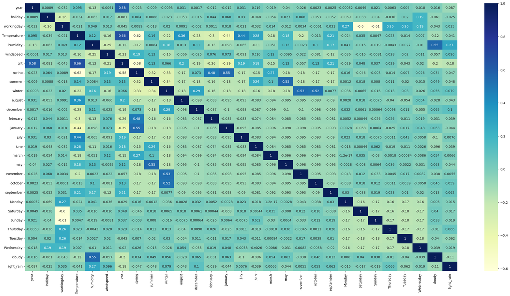

```python
# Let's check the correlation coefficients to see which variables are highly correlated
plt.figure(figsize = (30,15))
sns.heatmap(data_train.corr(),annot=True, cmap = "YlGnBu")
plt.show()
```

## Training The Model

```python
data.shape
```

```
(724, 29)
```

```python
y_train = data_train.pop('cnt')
X_train = data_train
```

```python
X_train.head()
```

|  | year | holiday | workingday | Temperature | humidity | windspeed | spring | summer | winter | august | december | february | january | july | june | march | may | november | october | september | Monday | Saturday | Sunday | Thursday | Tuesday | Wednesday | cloudy | light_rain |
| --- | --- | --- | --- | --- | --- | --- | --- | --- | --- | --- | --- | --- | --- | --- | --- | --- | --- | --- | --- | --- | --- | --- | --- | --- | --- | --- | --- | --- |
| 422 | 1 | 0 | 1 | 0.383206 | 0.281444 | 0.615256 | 1 | 0 | 0 | 0 | 0 | 1 | 0 | 0 | 0 | 0 | 0 | 0 | 0 | 0 | 0 | 0 | 0 | 0 | 0 | 1 | 0 | 0 |
| 728 | 1 | 0 | 1 | 0.245101 | 0.270255 | 0.822447 | 1 | 0 | 0 | 0 | 1 | 0 | 0 | 0 | 0 | 0 | 0 | 0 | 0 | 0 | 1 | 0 | 0 | 0 | 0 | 0 | 0 | 0 |
| 614 | 1 | 0 | 0 | 0.802708 | 0.647560 | 0.373836 | 0 | 0 | 0 | 0 | 0 | 0 | 0 | 0 | 0 | 0 | 0 | 0 | 0 | 1 | 0 | 1 | 0 | 0 | 0 | 0 | 0 | 0 |
| 113 | 0 | 0 | 1 | 0.651106 | 0.758823 | 0.425255 | 0 | 1 | 0 | 0 | 0 | 0 | 0 | 0 | 0 | 0 | 0 | 0 | 0 | 0 | 0 | 0 | 0 | 0 | 1 | 0 | 1 | 0 |
| 579 | 1 | 0 | 0 | 0.880586 | 0.507702 | 0.484409 | 0 | 0 | 0 | 1 | 0 | 0 | 0 | 0 | 0 | 0 | 0 | 0 | 0 | 0 | 0 | 1 | 0 | 0 | 0 | 0 | 1 | 0 |

```python
y_train.head()
```

```
422    0.469757
728    0.164795
614    0.853918
113    0.453942
579    0.814198
Name: cnt, dtype: float64
```

## Model 1

Lets try all all the vaibles in linear regression model using statistical analysis

```python
import statsmodels.api as sm
```

```python
X_train_lm = sm.add_constant(X_train)
```

```python
m1 = sm.OLS(y_train, X_train_lm).fit()
```

```python
m1.params
```

```
const          0.377624
year           0.242509
holiday       -0.164266
workingday    -0.104056
Temperature    0.467470
humidity      -0.147343
windspeed     -0.119137
spring        -0.090295
summer         0.017066
winter         0.106043
august        -0.002092
december      -0.068920
february      -0.035135
january       -0.061048
july          -0.037722
june          -0.004828
march          0.004660
may            0.035879
november      -0.075464
october        0.007204
september      0.067729
Monday        -0.010415
Saturday      -0.094819
Sunday        -0.094949
Thursday       0.008495
Tuesday       -0.028485
Wednesday     -0.002381
cloudy        -0.048702
light_rain    -0.182129
dtype: float64
```

```python
print(m1.summary())
```

```
                            OLS Regression Results
==============================================================================
Dep. Variable:                    cnt   R-squared:                       0.859
Model:                            OLS   Adj. R-squared:                  0.851
Method:                 Least Squares   F-statistic:                     103.9
Date:                Tue, 11 Mar 2025   Prob (F-statistic):          2.65e-183
Time:                        11:11:02   Log-Likelihood:                 504.01
No. Observations:                 506   AIC:                            -950.0
Df Residuals:                     477   BIC:                            -827.4
Df Model:                          28
Covariance Type:            nonrobust
===============================================================================
                  coef    std err          t      P>|t|      [0.025      0.975]
-------------------------------------------------------------------------------
const           0.3776      0.086      4.388      0.000       0.209       0.547
year            0.2425      0.008     28.564      0.000       0.226       0.259
holiday        -0.1643      0.066     -2.470      0.014      -0.295      -0.034
workingday     -0.1041      0.072     -1.450      0.148      -0.245       0.037
Temperature     0.4675      0.048      9.684      0.000       0.373       0.562
humidity       -0.1473      0.030     -4.888      0.000      -0.207      -0.088
windspeed      -0.1191      0.024     -4.977      0.000      -0.166      -0.072
spring         -0.0903      0.031     -2.899      0.004      -0.152      -0.029
summer          0.0171      0.028      0.610      0.542      -0.038       0.072
winter          0.1060      0.028      3.820      0.000       0.052       0.161
august         -0.0021      0.036     -0.059      0.953      -0.072       0.068
december       -0.0689      0.035     -1.993      0.047      -0.137      -0.001
february       -0.0351      0.035     -1.012      0.312      -0.103       0.033
january        -0.0610      0.035     -1.741      0.082      -0.130       0.008
july           -0.0377      0.036     -1.037      0.300      -0.109       0.034
june           -0.0048      0.026     -0.184      0.854      -0.056       0.047
march           0.0047      0.026      0.179      0.858      -0.047       0.056
may             0.0359      0.022      1.664      0.097      -0.007       0.078
november       -0.0755      0.037     -2.021      0.044      -0.149      -0.002
october         0.0072      0.037      0.196      0.845      -0.065       0.079
september       0.0677      0.033      2.027      0.043       0.002       0.133
Monday         -0.0104      0.016     -0.648      0.517      -0.042       0.021
Saturday       -0.0948      0.072     -1.309      0.191      -0.237       0.048
Sunday         -0.0949      0.072     -1.311      0.191      -0.237       0.047
Thursday        0.0085      0.016      0.535      0.593      -0.023       0.040
Tuesday        -0.0285      0.016     -1.832      0.068      -0.059       0.002
Wednesday      -0.0024      0.016     -0.150      0.881      -0.034       0.029
cloudy         -0.0487      0.012     -4.182      0.000      -0.072      -0.026
light_rain     -0.1821      0.035     -5.252      0.000      -0.250      -0.114
==============================================================================
Omnibus:                      109.188   Durbin-Watson:                   1.939
Prob(Omnibus):                  0.000   Jarque-Bera (JB):              296.697
Skew:                          -1.050   Prob(JB):                     3.74e-65
Kurtosis:                       6.108   Cond. No.                         68.0
==============================================================================

Notes:
[1] Standard Errors assume that the covariance matrix of the errors is correctly specified.
```

##### Checking Multicolinearity Using VIF

```python
from statsmodels.stats.outliers_influence import variance_inflation_factor
```

```python
vif = pd.DataFrame()
X = X_train
vif['Features'] = X.columns
vif['VIF'] = [variance_inflation_factor(X.values,i) for i in range (X.shape[1])]
vif['VIF'] = round(vif['VIF'],2)
vif = vif.sort_values(by = 'VIF', ascending= False)
vif
```

|  | Features | VIF |
| --- | --- | --- |
| 2 | workingday | 55.75 |
| 3 | Temperature | 42.31 |
| 4 | humidity | 15.48 |
| 6 | spring | 13.28 |
| 22 | Sunday | 12.05 |
| 21 | Saturday | 11.84 |
| 8 | winter | 11.57 |
| 7 | summer | 10.05 |
| 5 | windspeed | 7.24 |
| 17 | november | 6.79 |
| 18 | october | 6.40 |
| 13 | july | 6.35 |
| 9 | august | 5.98 |
| 10 | december | 5.93 |
| 12 | january | 5.88 |
| 19 | september | 4.95 |
| 11 | february | 4.57 |
| 15 | march | 3.30 |
| 26 | cloudy | 2.99 |
| 1 | holiday | 2.95 |
| 14 | june | 2.79 |
| 16 | may | 2.45 |
| 24 | Tuesday | 2.26 |
| 0 | year | 2.18 |
| 25 | Wednesday | 2.17 |
| 20 | Monday | 2.08 |
| 23 | Thursday | 2.07 |
| 27 | light_rain | 1.42 |

The VIF value should be less than 5 it can be seen there very high vif value and high p value lets take top 20 features with RFE

## Recursive Feature Elimination

```python
from sklearn.feature_selection import RFE

from sklearn.linear_model import LinearRegression
```

```python
lm = LinearRegression()
lm.fit(X_train,y_train)

rfe = RFE(lm, n_features_to_select=20, step = 1)
rfe = rfe.fit(X_train, y_train)
```

```python
rfe_ranking = pd.DataFrame(list(zip(X_train.columns, rfe.support_,rfe.ranking_)), columns=['features','Support',"Rank"])
rfe_ranking.sort_values(by='Rank', ascending = True)
```

|  | features | Support | Rank |
| --- | --- | --- | --- |
| 0 | year | True | 1 |
| 24 | Tuesday | True | 1 |
| 22 | Sunday | True | 1 |
| 21 | Saturday | True | 1 |
| 19 | september | True | 1 |
| 17 | november | True | 1 |
| 16 | may | True | 1 |
| 26 | cloudy | True | 1 |
| 12 | january | True | 1 |
| 11 | february | True | 1 |
| 13 | july | True | 1 |
| 4 | humidity | True | 1 |
| 1 | holiday | True | 1 |
| 2 | workingday | True | 1 |
| 3 | Temperature | True | 1 |
| 10 | december | True | 1 |
| 5 | windspeed | True | 1 |
| 27 | light_rain | True | 1 |
| 8 | winter | True | 1 |
| 6 | spring | True | 1 |
| 7 | summer | False | 2 |
| 23 | Thursday | False | 3 |
| 20 | Monday | False | 4 |
| 18 | october | False | 5 |
| 15 | march | False | 6 |
| 14 | june | False | 7 |
| 25 | Wednesday | False | 8 |
| 9 | august | False | 9 |

```python
col = X_train.columns[rfe.support_]
col
```

```
Index(['year', 'holiday', 'workingday', 'Temperature', 'humidity', 'windspeed',
       'spring', 'winter', 'december', 'february', 'january', 'july', 'may',
       'november', 'september', 'Saturday', 'Sunday', 'Tuesday', 'cloudy',
       'light_rain'],
      dtype='object')
```

```python
X_train.columns[~rfe.support_]
```

```
Index(['summer', 'august', 'june', 'march', 'october', 'Monday', 'Thursday',
       'Wednesday'],
      dtype='object')
```

```python
X_train_rfe = X_train[col]
```

```python
X_train_rfe.head()
```

|  | year | holiday | workingday | Temperature | humidity | windspeed | spring | winter | december | february | january | july | may | november | september | Saturday | Sunday | Tuesday | cloudy | light_rain |
| --- | --- | --- | --- | --- | --- | --- | --- | --- | --- | --- | --- | --- | --- | --- | --- | --- | --- | --- | --- | --- |
| 422 | 1 | 0 | 1 | 0.383206 | 0.281444 | 0.615256 | 1 | 0 | 0 | 1 | 0 | 0 | 0 | 0 | 0 | 0 | 0 | 0 | 0 | 0 |
| 728 | 1 | 0 | 1 | 0.245101 | 0.270255 | 0.822447 | 1 | 0 | 1 | 0 | 0 | 0 | 0 | 0 | 0 | 0 | 0 | 0 | 0 | 0 |
| 614 | 1 | 0 | 0 | 0.802708 | 0.647560 | 0.373836 | 0 | 0 | 0 | 0 | 0 | 0 | 0 | 0 | 1 | 1 | 0 | 0 | 0 | 0 |
| 113 | 0 | 0 | 1 | 0.651106 | 0.758823 | 0.425255 | 0 | 0 | 0 | 0 | 0 | 0 | 0 | 0 | 0 | 0 | 0 | 1 | 1 | 0 |
| 579 | 1 | 0 | 0 | 0.880586 | 0.507702 | 0.484409 | 0 | 0 | 0 | 0 | 0 | 0 | 0 | 0 | 0 | 1 | 0 | 0 | 1 | 0 |

## Model 2 : Using RFE

```python
X_train_lm = sm.add_constant(X_train_rfe)
```

```python
lm = sm.OLS(y_train, X_train_rfe).fit()
```

```python
print(lm.summary())
```

```
                                 OLS Regression Results
=======================================================================================
Dep. Variable:                    cnt   R-squared (uncentered):                   0.972
Model:                            OLS   Adj. R-squared (uncentered):              0.971
Method:                 Least Squares   F-statistic:                              836.4
Date:                Tue, 11 Mar 2025   Prob (F-statistic):                        0.00
Time:                        11:11:07   Log-Likelihood:                          489.37
No. Observations:                 506   AIC:                                     -938.7
Df Residuals:                     486   BIC:                                     -854.2
Df Model:                          20
Covariance Type:            nonrobust
===============================================================================
                  coef    std err          t      P>|t|      [0.025      0.975]
-------------------------------------------------------------------------------
year            0.2472      0.009     28.910      0.000       0.230       0.264
holiday         0.1302      0.034      3.853      0.000       0.064       0.197
workingday      0.2350      0.027      8.863      0.000       0.183       0.287
Temperature     0.5014      0.034     14.833      0.000       0.435       0.568
humidity       -0.1380      0.030     -4.606      0.000      -0.197      -0.079
windspeed      -0.0944      0.024     -3.977      0.000      -0.141      -0.048
spring         -0.0814      0.019     -4.295      0.000      -0.119      -0.044
winter          0.1145      0.015      7.733      0.000       0.085       0.144
december       -0.0694      0.018     -3.811      0.000      -0.105      -0.034
february       -0.0317      0.023     -1.391      0.165      -0.076       0.013
january        -0.0560      0.022     -2.536      0.012      -0.099      -0.013
july           -0.0437      0.018     -2.427      0.016      -0.079      -0.008
may             0.0517      0.016      3.168      0.002       0.020       0.084
november       -0.0812      0.019     -4.180      0.000      -0.119      -0.043
september       0.0619      0.017      3.709      0.000       0.029       0.095
Saturday        0.2423      0.028      8.751      0.000       0.188       0.297
Sunday          0.2416      0.028      8.764      0.000       0.187       0.296
Tuesday        -0.0254      0.012     -2.114      0.035      -0.049      -0.002
cloudy         -0.0457      0.012     -3.892      0.000      -0.069      -0.023
light_rain     -0.1798      0.035     -5.160      0.000      -0.248      -0.111
==============================================================================
Omnibus:                      113.859   Durbin-Watson:                   1.973
Prob(Omnibus):                  0.000   Jarque-Bera (JB):              325.332
Skew:                          -1.076   Prob(JB):                     2.26e-71
Kurtosis:                       6.287   Cond. No.                         20.0
==============================================================================

Notes:
[1] R² is computed without centering (uncentered) since the model does not contain a constant.
[2] Standard Errors assume that the covariance matrix of the errors is correctly specified.
```

Checking VIF

```python
vif = pd.DataFrame()
X = X_train_rfe
vif['Features'] = X.columns
vif['VIF'] = [variance_inflation_factor(X.values,i) for i in range (X.shape[1])]
vif['VIF'] = round(vif['VIF'],2)
vif = vif.sort_values(by = 'VIF', ascending= False)
vif
```

|  | Features | VIF |
| --- | --- | --- |
| 2 | workingday | 27.61 |
| 3 | Temperature | 22.29 |
| 4 | humidity | 14.72 |
| 5 | windspeed | 6.96 |
| 16 | Sunday | 6.47 |
| 15 | Saturday | 6.27 |
| 6 | spring | 5.01 |
| 7 | winter | 3.24 |
| 18 | cloudy | 2.93 |
| 10 | january | 2.49 |
| 0 | year | 2.13 |
| 9 | february | 2.06 |
| 1 | holiday | 1.94 |
| 13 | november | 1.93 |
| 8 | december | 1.77 |
| 11 | july | 1.58 |
| 19 | light_rain | 1.38 |
| 12 | may | 1.36 |
| 17 | Tuesday | 1.31 |
| 14 | september | 1.30 |

Dropping Feature `workingday` based on high vif variable

```python
X_train_rfe = X_train_rfe.drop(['workingday'], axis = 1)
```

## Model 3

```python
X_train_lm = sm.add_constant(X_train_rfe)


m3 = sm.OLS(y_train, X_train_lm).fit()


print(m3.summary())
```

```
                            OLS Regression Results
==============================================================================
Dep. Variable:                    cnt   R-squared:                       0.858
Model:                            OLS   Adj. R-squared:                  0.852
Method:                 Least Squares   F-statistic:                     154.2
Date:                Tue, 11 Mar 2025   Prob (F-statistic):          7.94e-192
Time:                        11:11:09   Log-Likelihood:                 501.56
No. Observations:                 506   AIC:                            -963.1
Df Residuals:                     486   BIC:                            -878.6
Df Model:                          19
Covariance Type:            nonrobust
===============================================================================
                  coef    std err          t      P>|t|      [0.025      0.975]
-------------------------------------------------------------------------------
const           0.2914      0.028     10.316      0.000       0.236       0.347
year            0.2439      0.008     29.131      0.000       0.227       0.260
holiday        -0.0726      0.024     -2.980      0.003      -0.121      -0.025
Temperature     0.4482      0.035     12.907      0.000       0.380       0.516
humidity       -0.1489      0.029     -5.087      0.000      -0.206      -0.091
windspeed      -0.1156      0.024     -4.917      0.000      -0.162      -0.069
spring         -0.0978      0.019     -5.202      0.000      -0.135      -0.061
winter          0.1031      0.015      7.045      0.000       0.074       0.132
december       -0.0784      0.018     -4.388      0.000      -0.113      -0.043
february       -0.0418      0.022     -1.872      0.062      -0.086       0.002
january        -0.0696      0.022     -3.201      0.001      -0.112      -0.027
july           -0.0410      0.018     -2.333      0.020      -0.076      -0.006
may             0.0465      0.016      2.913      0.004       0.015       0.078
november       -0.0865      0.019     -4.557      0.000      -0.124      -0.049
september       0.0618      0.016      3.796      0.000       0.030       0.094
Saturday        0.0087      0.012      0.716      0.474      -0.015       0.033
Sunday          0.0080      0.012      0.671      0.502      -0.015       0.032
Tuesday        -0.0271      0.012     -2.315      0.021      -0.050      -0.004
cloudy         -0.0472      0.011     -4.121      0.000      -0.070      -0.025
light_rain     -0.1791      0.034     -5.268      0.000      -0.246      -0.112
==============================================================================
Omnibus:                      109.357   Durbin-Watson:                   1.938
Prob(Omnibus):                  0.000   Jarque-Bera (JB):              302.518
Skew:                          -1.045   Prob(JB):                     2.04e-66
Kurtosis:                       6.159   Cond. No.                         17.4
==============================================================================

Notes:
[1] Standard Errors assume that the covariance matrix of the errors is correctly specified.
```

```python
vif = pd.DataFrame()
X = X_train_rfe
vif['Features'] = X.columns
vif['VIF'] = [variance_inflation_factor(X.values,i) for i in range (X.shape[1])]
vif['VIF'] = round(vif['VIF'],2)
vif = vif.sort_values(by = 'VIF', ascending= False)
vif
```

|  | Features | VIF |
| --- | --- | --- |
| 3 | humidity | 13.42 |
| 2 | Temperature | 12.43 |
| 4 | windspeed | 5.33 |
| 5 | spring | 4.45 |
| 17 | cloudy | 2.92 |
| 6 | winter | 2.90 |
| 9 | january | 2.35 |
| 0 | year | 2.12 |
| 8 | february | 2.00 |
| 12 | november | 1.86 |
| 7 | december | 1.71 |
| 10 | july | 1.56 |
| 18 | light_rain | 1.37 |
| 11 | may | 1.36 |
| 16 | Tuesday | 1.30 |
| 13 | september | 1.29 |
| 14 | Saturday | 1.26 |
| 15 | Sunday | 1.26 |
| 1 | holiday | 1.06 |

Dropping Feature `humidity` based on high vif variable

```python
X_train_rfe = X_train_rfe.drop(['humidity'], axis = 1)
```

# Model 4

```python
X_train_lm = sm.add_constant(X_train_rfe)


m4 = sm.OLS(y_train, X_train_lm).fit()


print(m4.summary())
```

```
                            OLS Regression Results
==============================================================================
Dep. Variable:                    cnt   R-squared:                       0.850
Model:                            OLS   Adj. R-squared:                  0.845
Method:                 Least Squares   F-statistic:                     153.5
Date:                Tue, 11 Mar 2025   Prob (F-statistic):          1.75e-187
Time:                        11:11:11   Log-Likelihood:                 488.44
No. Observations:                 506   AIC:                            -938.9
Df Residuals:                     487   BIC:                            -858.6
Df Model:                          18
Covariance Type:            nonrobust
===============================================================================
                  coef    std err          t      P>|t|      [0.025      0.975]
-------------------------------------------------------------------------------
const           0.2487      0.028      8.994      0.000       0.194       0.303
year            0.2508      0.008     29.622      0.000       0.234       0.267
holiday        -0.0707      0.025     -2.827      0.005      -0.120      -0.022
Temperature     0.4016      0.034     11.695      0.000       0.334       0.469
windspeed      -0.0841      0.023     -3.618      0.000      -0.130      -0.038
spring         -0.1065      0.019     -5.546      0.000      -0.144      -0.069
winter          0.0935      0.015      6.281      0.000       0.064       0.123
december       -0.0885      0.018     -4.865      0.000      -0.124      -0.053
february       -0.0425      0.023     -1.854      0.064      -0.087       0.003
january        -0.0720      0.022     -3.228      0.001      -0.116      -0.028
july           -0.0305      0.018     -1.704      0.089      -0.066       0.005
may             0.0349      0.016      2.154      0.032       0.003       0.067
november       -0.0918      0.019     -4.725      0.000      -0.130      -0.054
september       0.0531      0.017      3.198      0.001       0.020       0.086
Saturday        0.0120      0.012      0.960      0.337      -0.013       0.037
Sunday          0.0110      0.012      0.896      0.371      -0.013       0.035
Tuesday        -0.0306      0.012     -2.552      0.011      -0.054      -0.007
cloudy         -0.0851      0.009     -9.528      0.000      -0.103      -0.068
light_rain     -0.2573      0.031     -8.276      0.000      -0.318      -0.196
==============================================================================
Omnibus:                      105.198   Durbin-Watson:                   1.892
Prob(Omnibus):                  0.000   Jarque-Bera (JB):              292.588
Skew:                          -1.004   Prob(JB):                     2.92e-64
Kurtosis:                       6.138   Cond. No.                         16.3
==============================================================================

Notes:
[1] Standard Errors assume that the covariance matrix of the errors is correctly specified.
```

```python
vif = pd.DataFrame()
X = X_train_rfe
vif['Features'] = X.columns
vif['VIF'] = [variance_inflation_factor(X.values,i) for i in range (X.shape[1])]
vif['VIF'] = round(vif['VIF'],2)
vif = vif.sort_values(by = 'VIF', ascending= False)
vif
```

|  | Features | VIF |
| --- | --- | --- |
| 2 | Temperature | 6.37 |
| 3 | windspeed | 5.23 |
| 4 | spring | 4.22 |
| 5 | winter | 2.70 |
| 8 | january | 2.32 |
| 0 | year | 2.08 |
| 7 | february | 2.00 |
| 11 | november | 1.83 |
| 6 | december | 1.65 |
| 16 | cloudy | 1.62 |
| 9 | july | 1.52 |
| 10 | may | 1.32 |
| 15 | Tuesday | 1.29 |
| 12 | september | 1.28 |
| 13 | Saturday | 1.26 |
| 14 | Sunday | 1.26 |
| 17 | light_rain | 1.09 |
| 1 | holiday | 1.06 |

Dropping Feature `windspeed` based on high vif variable

```python
X_train_rfe = X_train_rfe.drop(['windspeed'], axis = 1)
```

# Model 5

```python
X_train_lm = sm.add_constant(X_train_rfe)


m5 = sm.OLS(y_train, X_train_lm).fit()


print(m5.summary())
```

```
                            OLS Regression Results
==============================================================================
Dep. Variable:                    cnt   R-squared:                       0.846
Model:                            OLS   Adj. R-squared:                  0.841
Method:                 Least Squares   F-statistic:                     157.9
Date:                Tue, 11 Mar 2025   Prob (F-statistic):          8.41e-186
Time:                        11:11:13   Log-Likelihood:                 481.73
No. Observations:                 506   AIC:                            -927.5
Df Residuals:                     488   BIC:                            -851.4
Df Model:                          17
Covariance Type:            nonrobust
===============================================================================
                  coef    std err          t      P>|t|      [0.025      0.975]
-------------------------------------------------------------------------------
const           0.2021      0.025      8.159      0.000       0.153       0.251
year            0.2502      0.009     29.191      0.000       0.233       0.267
holiday        -0.0712      0.025     -2.814      0.005      -0.121      -0.021
Temperature     0.4156      0.035     12.030      0.000       0.348       0.483
spring         -0.1097      0.019     -5.652      0.000      -0.148      -0.072
winter          0.1021      0.015      6.864      0.000       0.073       0.131
december       -0.0850      0.018     -4.618      0.000      -0.121      -0.049
february       -0.0367      0.023     -1.588      0.113      -0.082       0.009
january        -0.0647      0.022     -2.877      0.004      -0.109      -0.021
july           -0.0262      0.018     -1.448      0.148      -0.062       0.009
may             0.0368      0.016      2.247      0.025       0.005       0.069
november       -0.0933      0.020     -4.748      0.000      -0.132      -0.055
september       0.0592      0.017      3.543      0.000       0.026       0.092
Saturday        0.0122      0.013      0.968      0.333      -0.013       0.037
Sunday          0.0110      0.012      0.888      0.375      -0.013       0.035
Tuesday        -0.0321      0.012     -2.641      0.009      -0.056      -0.008
cloudy         -0.0835      0.009     -9.246      0.000      -0.101      -0.066
light_rain     -0.2701      0.031     -8.639      0.000      -0.331      -0.209
==============================================================================
Omnibus:                      101.379   Durbin-Watson:                   1.943
Prob(Omnibus):                  0.000   Jarque-Bera (JB):              282.326
Skew:                          -0.968   Prob(JB):                     4.94e-62
Kurtosis:                       6.106   Cond. No.                         15.1
==============================================================================

Notes:
[1] Standard Errors assume that the covariance matrix of the errors is correctly specified.
```

```python
vif = pd.DataFrame()
X = X_train_rfe
vif['Features'] = X.columns
vif['VIF'] = [variance_inflation_factor(X.values,i) for i in range (X.shape[1])]
vif['VIF'] = round(vif['VIF'],2)
vif = vif.sort_values(by = 'VIF', ascending= False)
vif
```

|  | Features | VIF |
| --- | --- | --- |
| 2 | Temperature | 4.01 |
| 3 | spring | 3.83 |
| 4 | winter | 2.69 |
| 7 | january | 2.31 |
| 0 | year | 2.07 |
| 6 | february | 1.99 |
| 10 | november | 1.79 |
| 5 | december | 1.64 |
| 15 | cloudy | 1.62 |
| 8 | july | 1.48 |
| 9 | may | 1.31 |
| 14 | Tuesday | 1.28 |
| 11 | september | 1.27 |
| 12 | Saturday | 1.26 |
| 13 | Sunday | 1.26 |
| 1 | holiday | 1.06 |
| 16 | light_rain | 1.06 |

Dropping Feature `Sunday` based on high p Value

```python
X_train_rfe = X_train_rfe.drop(['Sunday'], axis = 1)
```

## Model 6

```python
X_train_lm = sm.add_constant(X_train_rfe)


m6 = sm.OLS(y_train, X_train_lm).fit()


print(m6.summary())
```

```
                            OLS Regression Results
==============================================================================
Dep. Variable:                    cnt   R-squared:                       0.846
Model:                            OLS   Adj. R-squared:                  0.841
Method:                 Least Squares   F-statistic:                     167.8
Date:                Tue, 11 Mar 2025   Prob (F-statistic):          9.45e-187
Time:                        11:11:14   Log-Likelihood:                 481.32
No. Observations:                 506   AIC:                            -928.6
Df Residuals:                     489   BIC:                            -856.8
Df Model:                          16
Covariance Type:            nonrobust
===============================================================================
                  coef    std err          t      P>|t|      [0.025      0.975]
-------------------------------------------------------------------------------
const           0.2047      0.025      8.329      0.000       0.156       0.253
year            0.2503      0.009     29.225      0.000       0.234       0.267
holiday        -0.0721      0.025     -2.853      0.005      -0.122      -0.022
Temperature     0.4150      0.035     12.017      0.000       0.347       0.483
spring         -0.1097      0.019     -5.653      0.000      -0.148      -0.072
winter          0.1020      0.015      6.863      0.000       0.073       0.131
december       -0.0851      0.018     -4.627      0.000      -0.121      -0.049
february       -0.0374      0.023     -1.617      0.107      -0.083       0.008
january        -0.0650      0.022     -2.894      0.004      -0.109      -0.021
july           -0.0260      0.018     -1.437      0.151      -0.061       0.010
may             0.0368      0.016      2.249      0.025       0.005       0.069
november       -0.0938      0.020     -4.772      0.000      -0.132      -0.055
september       0.0594      0.017      3.555      0.000       0.027       0.092
Saturday        0.0099      0.012      0.799      0.425      -0.014       0.034
Tuesday        -0.0344      0.012     -2.906      0.004      -0.058      -0.011
cloudy         -0.0833      0.009     -9.226      0.000      -0.101      -0.066
light_rain     -0.2711      0.031     -8.679      0.000      -0.332      -0.210
==============================================================================
Omnibus:                       98.326   Durbin-Watson:                   1.942
Prob(Omnibus):                  0.000   Jarque-Bera (JB):              270.326
Skew:                          -0.944   Prob(JB):                     1.99e-59
Kurtosis:                       6.043   Cond. No.                         15.0
==============================================================================

Notes:
[1] Standard Errors assume that the covariance matrix of the errors is correctly specified.
```

```python
vif = pd.DataFrame()
X = X_train_rfe
vif['Features'] = X.columns
vif['VIF'] = [variance_inflation_factor(X.values,i) for i in range (X.shape[1])]
vif['VIF'] = round(vif['VIF'],2)
vif = vif.sort_values(by = 'VIF', ascending= False)
vif
```

|  | Features | VIF |
| --- | --- | --- |
| 2 | Temperature | 3.82 |
| 3 | spring | 3.82 |
| 4 | winter | 2.69 |
| 7 | january | 2.31 |
| 0 | year | 2.07 |
| 6 | february | 1.99 |
| 10 | november | 1.79 |
| 5 | december | 1.64 |
| 14 | cloudy | 1.61 |
| 8 | july | 1.48 |
| 9 | may | 1.31 |
| 11 | september | 1.27 |
| 13 | Tuesday | 1.23 |
| 12 | Saturday | 1.21 |
| 1 | holiday | 1.06 |
| 15 | light_rain | 1.06 |

Dropping Feature `Saturday` based on high p Value

```python
X_train_rfe = X_train_rfe.drop(['Saturday'], axis = 1)
```

## Model 7

```python
X_train_lm = sm.add_constant(X_train_rfe)


m7 = sm.OLS(y_train, X_train_lm).fit()


print(m7.summary())
```

```
                            OLS Regression Results
==============================================================================
Dep. Variable:                    cnt   R-squared:                       0.846
Model:                            OLS   Adj. R-squared:                  0.841
Method:                 Least Squares   F-statistic:                     179.0
Date:                Tue, 11 Mar 2025   Prob (F-statistic):          9.53e-188
Time:                        11:11:16   Log-Likelihood:                 480.99
No. Observations:                 506   AIC:                            -930.0
Df Residuals:                     490   BIC:                            -862.4
Df Model:                          15
Covariance Type:            nonrobust
===============================================================================
                  coef    std err          t      P>|t|      [0.025      0.975]
-------------------------------------------------------------------------------
const           0.2065      0.024      8.437      0.000       0.158       0.255
year            0.2503      0.009     29.237      0.000       0.234       0.267
holiday        -0.0727      0.025     -2.879      0.004      -0.122      -0.023
Temperature     0.4150      0.035     12.023      0.000       0.347       0.483
spring         -0.1100      0.019     -5.669      0.000      -0.148      -0.072
winter          0.1019      0.015      6.855      0.000       0.073       0.131
december       -0.0850      0.018     -4.624      0.000      -0.121      -0.049
february       -0.0373      0.023     -1.615      0.107      -0.083       0.008
january        -0.0657      0.022     -2.927      0.004      -0.110      -0.022
july           -0.0258      0.018     -1.430      0.153      -0.061       0.010
may             0.0365      0.016      2.230      0.026       0.004       0.069
november       -0.0936      0.020     -4.766      0.000      -0.132      -0.055
september       0.0588      0.017      3.524      0.000       0.026       0.092
Tuesday        -0.0361      0.012     -3.093      0.002      -0.059      -0.013
cloudy         -0.0830      0.009     -9.206      0.000      -0.101      -0.065
light_rain     -0.2717      0.031     -8.705      0.000      -0.333      -0.210
==============================================================================
Omnibus:                       99.001   Durbin-Watson:                   1.939
Prob(Omnibus):                  0.000   Jarque-Bera (JB):              274.529
Skew:                          -0.947   Prob(JB):                     2.44e-60
Kurtosis:                       6.071   Cond. No.                         14.9
==============================================================================

Notes:
[1] Standard Errors assume that the covariance matrix of the errors is correctly specified.
```

```python
vif = pd.DataFrame()
X = X_train_rfe
vif['Features'] = X.columns
vif['VIF'] = [variance_inflation_factor(X.values,i) for i in range (X.shape[1])]
vif['VIF'] = round(vif['VIF'],2)
vif = vif.sort_values(by = 'VIF', ascending= False)
vif
```

|  | Features | VIF |
| --- | --- | --- |
| 3 | spring | 3.81 |
| 2 | Temperature | 3.66 |
| 4 | winter | 2.68 |
| 7 | january | 2.31 |
| 0 | year | 2.07 |
| 6 | february | 1.99 |
| 10 | november | 1.79 |
| 5 | december | 1.63 |
| 13 | cloudy | 1.61 |
| 8 | july | 1.48 |
| 9 | may | 1.31 |
| 11 | september | 1.26 |
| 12 | Tuesday | 1.19 |
| 1 | holiday | 1.06 |
| 14 | light_rain | 1.06 |

Dropping Feature `july` based on high p Value

```python
X_train_rfe = X_train_rfe.drop(['july'], axis = 1)
```

# Model 8

```python
X_train_lm = sm.add_constant(X_train_rfe)


m8 = sm.OLS(y_train, X_train_lm).fit()


print(m8.summary())
```

```
                            OLS Regression Results
==============================================================================
Dep. Variable:                    cnt   R-squared:                       0.845
Model:                            OLS   Adj. R-squared:                  0.841
Method:                 Least Squares   F-statistic:                     191.3
Date:                Tue, 11 Mar 2025   Prob (F-statistic):          1.87e-188
Time:                        11:11:17   Log-Likelihood:                 479.93
No. Observations:                 506   AIC:                            -929.9
Df Residuals:                     491   BIC:                            -866.5
Df Model:                          14
Covariance Type:            nonrobust
===============================================================================
                  coef    std err          t      P>|t|      [0.025      0.975]
-------------------------------------------------------------------------------
const           0.2140      0.024      8.945      0.000       0.167       0.261
year            0.2508      0.009     29.272      0.000       0.234       0.268
holiday        -0.0739      0.025     -2.924      0.004      -0.123      -0.024
Temperature     0.3957      0.032     12.444      0.000       0.333       0.458
spring         -0.1096      0.019     -5.645      0.000      -0.148      -0.071
winter          0.1039      0.015      7.011      0.000       0.075       0.133
december       -0.0873      0.018     -4.765      0.000      -0.123      -0.051
february       -0.0396      0.023     -1.718      0.086      -0.085       0.006
january        -0.0693      0.022     -3.106      0.002      -0.113      -0.025
may             0.0418      0.016      2.621      0.009       0.010       0.073
november       -0.0955      0.020     -4.868      0.000      -0.134      -0.057
september       0.0643      0.016      3.956      0.000       0.032       0.096
Tuesday        -0.0371      0.012     -3.190      0.002      -0.060      -0.014
cloudy         -0.0829      0.009     -9.183      0.000      -0.101      -0.065
light_rain     -0.2740      0.031     -8.782      0.000      -0.335      -0.213
==============================================================================
Omnibus:                      101.339   Durbin-Watson:                   1.935
Prob(Omnibus):                  0.000   Jarque-Bera (JB):              282.861
Skew:                          -0.967   Prob(JB):                     3.78e-62
Kurtosis:                       6.111   Cond. No.                         14.0
==============================================================================

Notes:
[1] Standard Errors assume that the covariance matrix of the errors is correctly specified.
```

```python
vif = pd.DataFrame()
X = X_train_rfe
vif['Features'] = X.columns
vif['VIF'] = [variance_inflation_factor(X.values,i) for i in range (X.shape[1])]
vif['VIF'] = round(vif['VIF'],2)
vif = vif.sort_values(by = 'VIF', ascending= False)
vif
```

|  | Features | VIF |
| --- | --- | --- |
| 3 | spring | 3.73 |
| 2 | Temperature | 2.76 |
| 4 | winter | 2.58 |
| 7 | january | 2.30 |
| 0 | year | 2.06 |
| 6 | february | 1.99 |
| 9 | november | 1.79 |
| 5 | december | 1.63 |
| 12 | cloudy | 1.60 |
| 8 | may | 1.22 |
| 10 | september | 1.20 |
| 11 | Tuesday | 1.19 |
| 1 | holiday | 1.06 |
| 13 | light_rain | 1.06 |

Dropping Feature `february` based on high P value

```python
X_train_rfe = X_train_rfe.drop(['february'], axis = 1)
```

## Model 9

```python
X_train_lm = sm.add_constant(X_train_rfe)


m9 = sm.OLS(y_train, X_train_lm).fit()


print(m9.summary())
```

```
                            OLS Regression Results
==============================================================================
Dep. Variable:                    cnt   R-squared:                       0.844
Model:                            OLS   Adj. R-squared:                  0.840
Method:                 Least Squares   F-statistic:                     204.9
Date:                Tue, 11 Mar 2025   Prob (F-statistic):          5.54e-189
Time:                        11:11:19   Log-Likelihood:                 478.42
No. Observations:                 506   AIC:                            -928.8
Df Residuals:                     492   BIC:                            -869.7
Df Model:                          13
Covariance Type:            nonrobust
===============================================================================
                  coef    std err          t      P>|t|      [0.025      0.975]
-------------------------------------------------------------------------------
const           0.2065      0.024      8.761      0.000       0.160       0.253
year            0.2505      0.009     29.188      0.000       0.234       0.267
holiday        -0.0761      0.025     -3.009      0.003      -0.126      -0.026
Temperature     0.4060      0.031     12.980      0.000       0.345       0.468
spring         -0.1255      0.017     -7.336      0.000      -0.159      -0.092
winter          0.1023      0.015      6.904      0.000       0.073       0.131
december       -0.0772      0.017     -4.440      0.000      -0.111      -0.043
january        -0.0483      0.019     -2.582      0.010      -0.085      -0.012
may             0.0423      0.016      2.644      0.008       0.011       0.074
november       -0.0905      0.019     -4.655      0.000      -0.129      -0.052
september       0.0648      0.016      3.974      0.000       0.033       0.097
Tuesday        -0.0369      0.012     -3.162      0.002      -0.060      -0.014
cloudy         -0.0822      0.009     -9.097      0.000      -0.100      -0.064
light_rain     -0.2726      0.031     -8.723      0.000      -0.334      -0.211
==============================================================================
Omnibus:                       96.153   Durbin-Watson:                   1.934
Prob(Omnibus):                  0.000   Jarque-Bera (JB):              259.618
Skew:                          -0.930   Prob(JB):                     4.21e-57
Kurtosis:                       5.976   Cond. No.                         13.7
==============================================================================

Notes:
[1] Standard Errors assume that the covariance matrix of the errors is correctly specified.
```

```python
vif = pd.DataFrame()
X = X_train_rfe
vif['Features'] = X.columns
vif['VIF'] = [variance_inflation_factor(X.values,i) for i in range (X.shape[1])]
vif['VIF'] = round(vif['VIF'],2)
vif = vif.sort_values(by = 'VIF', ascending= False)
vif
```

|  | Features | VIF |
| --- | --- | --- |
| 2 | Temperature | 2.75 |
| 4 | winter | 2.52 |
| 0 | year | 2.06 |
| 3 | spring | 2.00 |
| 8 | november | 1.77 |
| 6 | january | 1.66 |
| 11 | cloudy | 1.60 |
| 5 | december | 1.49 |
| 7 | may | 1.22 |
| 9 | september | 1.20 |
| 10 | Tuesday | 1.19 |
| 12 | light_rain | 1.06 |
| 1 | holiday | 1.05 |

```python
X_train_rfe = X_train_rfe.drop(['january'], axis = 1)
```

## Final Model

```python
X_train_lm = sm.add_constant(X_train_rfe)


Final_model= sm.OLS(y_train, X_train_lm).fit()


print(Final_model.summary())
```

```
                            OLS Regression Results
==============================================================================
Dep. Variable:                    cnt   R-squared:                       0.842
Model:                            OLS   Adj. R-squared:                  0.838
Method:                 Least Squares   F-statistic:                     219.0
Date:                Tue, 11 Mar 2025   Prob (F-statistic):          9.90e-189
Time:                        11:11:22   Log-Likelihood:                 475.01
No. Observations:                 506   AIC:                            -924.0
Df Residuals:                     493   BIC:                            -869.1
Df Model:                          12
Covariance Type:            nonrobust
===============================================================================
                  coef    std err          t      P>|t|      [0.025      0.975]
-------------------------------------------------------------------------------
const           0.1944      0.023      8.367      0.000       0.149       0.240
year            0.2499      0.009     28.966      0.000       0.233       0.267
holiday        -0.0794      0.025     -3.129      0.002      -0.129      -0.030
Temperature     0.4242      0.031     13.834      0.000       0.364       0.484
spring         -0.1367      0.017     -8.218      0.000      -0.169      -0.104
winter          0.1026      0.015      6.888      0.000       0.073       0.132
december       -0.0667      0.017     -3.925      0.000      -0.100      -0.033
may             0.0433      0.016      2.691      0.007       0.012       0.075
november       -0.0849      0.019     -4.370      0.000      -0.123      -0.047
september       0.0648      0.016      3.956      0.000       0.033       0.097
Tuesday        -0.0374      0.012     -3.191      0.002      -0.060      -0.014
cloudy         -0.0831      0.009     -9.147      0.000      -0.101      -0.065
light_rain     -0.2716      0.031     -8.642      0.000      -0.333      -0.210
==============================================================================
Omnibus:                       90.162   Durbin-Watson:                   1.928
Prob(Omnibus):                  0.000   Jarque-Bera (JB):              229.215
Skew:                          -0.894   Prob(JB):                     1.68e-50
Kurtosis:                       5.770   Cond. No.                         13.4
==============================================================================

Notes:
[1] Standard Errors assume that the covariance matrix of the errors is correctly specified.
```

```python
vif = pd.DataFrame()
X = X_train_rfe
vif['Features'] = X.columns
vif['VIF'] = [variance_inflation_factor(X.values,i) for i in range (X.shape[1])]
vif['VIF'] = round(vif['VIF'],2)
vif = vif.sort_values(by = 'VIF', ascending= False)
vif
```

|  | Features | VIF |
| --- | --- | --- |
| 2 | Temperature | 2.72 |
| 4 | winter | 2.49 |
| 0 | year | 2.06 |
| 7 | november | 1.76 |
| 10 | cloudy | 1.59 |
| 5 | december | 1.44 |
| 3 | spring | 1.36 |
| 6 | may | 1.22 |
| 8 | september | 1.20 |
| 9 | Tuesday | 1.19 |
| 11 | light_rain | 1.06 |
| 1 | holiday | 1.05 |

```python
data.head()
```

|  | year | holiday | workingday | Temperature | humidity | windspeed | cnt | spring | summer | winter | august | december | february | january | july | june | march | may | november | october | september | Monday | Saturday | Sunday | Thursday | Tuesday | Wednesday | cloudy | light_rain |
| --- | --- | --- | --- | --- | --- | --- | --- | --- | --- | --- | --- | --- | --- | --- | --- | --- | --- | --- | --- | --- | --- | --- | --- | --- | --- | --- | --- | --- | --- |
| 0 | 0 | 0 | 1 | 14.110847 | 80.5833 | 10.749882 | 985 | 1 | 0 | 0 | 0 | 0 | 0 | 1 | 0 | 0 | 0 | 0 | 0 | 0 | 0 | 1 | 0 | 0 | 0 | 0 | 0 | 1 | 0 |
| 1 | 0 | 0 | 1 | 14.902598 | 69.6087 | 16.652113 | 801 | 1 | 0 | 0 | 0 | 0 | 0 | 1 | 0 | 0 | 0 | 0 | 0 | 0 | 0 | 0 | 0 | 0 | 0 | 1 | 0 | 1 | 0 |
| 2 | 0 | 0 | 1 | 8.050924 | 43.7273 | 16.636703 | 1349 | 1 | 0 | 0 | 0 | 0 | 0 | 1 | 0 | 0 | 0 | 0 | 0 | 0 | 0 | 0 | 0 | 0 | 0 | 0 | 1 | 0 | 0 |
| 3 | 0 | 0 | 1 | 8.200000 | 59.0435 | 10.739832 | 1562 | 1 | 0 | 0 | 0 | 0 | 0 | 1 | 0 | 0 | 0 | 0 | 0 | 0 | 0 | 0 | 0 | 0 | 1 | 0 | 0 | 0 | 0 |
| 4 | 0 | 0 | 1 | 9.305237 | 43.6957 | 12.522300 | 1600 | 1 | 0 | 0 | 0 | 0 | 0 | 1 | 0 | 0 | 0 | 0 | 0 | 0 | 0 | 0 | 0 | 0 | 0 | 0 | 0 | 0 | 0 |

# Residual Analysis of Train Data

```python
X_train_lm = sm.add_constant(X_train_rfe)
```

```python
y_train_pred = Final_model.predict(X_train_lm)
```

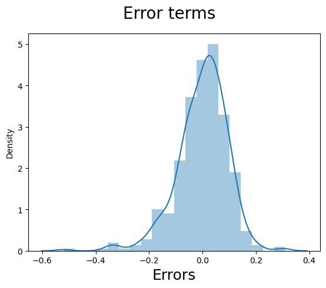

```python
fig = plt.figure()
sns.distplot((y_train - y_train_pred), bins = 20)
fig.suptitle('Error terms', fontsize = 20)
plt.xlabel('Errors', fontsize= 18)
```

# Predictions on test Data

```python
num_vars = ['Temperature','humidity','windspeed','cnt']

data_test[num_vars] = scaler.transform(data_test[num_vars])
```

```python
data_test.describe()
```

|  | year | holiday | workingday | Temperature | humidity | windspeed | cnt | spring | summer | winter | august | december | february | january | july | june | march | may | november | october | september | Monday | Saturday | Sunday | Thursday | Tuesday | Wednesday | cloudy | light_rain |
| --- | --- | --- | --- | --- | --- | --- | --- | --- | --- | --- | --- | --- | --- | --- | --- | --- | --- | --- | --- | --- | --- | --- | --- | --- | --- | --- | --- | --- | --- |
| count | 218.000000 | 218.000000 | 218.000000 | 218.000000 | 218.000000 | 218.000000 | 218.000000 | 218.000000 | 218.000000 | 218.000000 | 218.000000 | 218.000000 | 218.000000 | 218.000000 | 218.000000 | 218.000000 | 218.000000 | 218.000000 | 218.000000 | 218.000000 | 218.000000 | 218.000000 | 218.000000 | 218.00000 | 218.000000 | 218.000000 | 218.000000 | 218.000000 | 218.000000 |
| mean | 0.486239 | 0.027523 | 0.711009 | 0.560655 | 0.474024 | 0.408393 | 0.498156 | 0.247706 | 0.275229 | 0.215596 | 0.082569 | 0.068807 | 0.091743 | 0.077982 | 0.087156 | 0.114679 | 0.073394 | 0.077982 | 0.068807 | 0.082569 | 0.082569 | 0.155963 | 0.137615 | 0.12844 | 0.155963 | 0.110092 | 0.137615 | 0.261468 | 0.036697 |
| std | 0.500961 | 0.163978 | 0.454337 | 0.230041 | 0.199583 | 0.193546 | 0.215383 | 0.432674 | 0.447658 | 0.412182 | 0.275863 | 0.253709 | 0.289327 | 0.268760 | 0.282713 | 0.319367 | 0.261383 | 0.268760 | 0.253709 | 0.275863 | 0.275863 | 0.363656 | 0.345288 | 0.33535 | 0.363656 | 0.313724 | 0.345288 | 0.440446 | 0.188450 |
| min | 0.000000 | 0.000000 | 0.000000 | 0.046591 | -0.071617 | 0.049875 | 0.009055 | 0.000000 | 0.000000 | 0.000000 | 0.000000 | 0.000000 | 0.000000 | 0.000000 | 0.000000 | 0.000000 | 0.000000 | 0.000000 | 0.000000 | 0.000000 | 0.000000 | 0.000000 | 0.000000 | 0.00000 | 0.000000 | 0.000000 | 0.000000 | 0.000000 | 0.000000 |
| 25% | 0.000000 | 0.000000 | 0.000000 | 0.366546 | 0.336799 | 0.277259 | 0.353042 | 0.000000 | 0.000000 | 0.000000 | 0.000000 | 0.000000 | 0.000000 | 0.000000 | 0.000000 | 0.000000 | 0.000000 | 0.000000 | 0.000000 | 0.000000 | 0.000000 | 0.000000 | 0.000000 | 0.00000 | 0.000000 | 0.000000 | 0.000000 | 0.000000 | 0.000000 |
| 50% | 0.000000 | 0.000000 | 1.000000 | 0.576343 | 0.476623 | 0.373049 | 0.501751 | 0.000000 | 0.000000 | 0.000000 | 0.000000 | 0.000000 | 0.000000 | 0.000000 | 0.000000 | 0.000000 | 0.000000 | 0.000000 | 0.000000 | 0.000000 | 0.000000 | 0.000000 | 0.000000 | 0.00000 | 0.000000 | 0.000000 | 0.000000 | 0.000000 | 0.000000 |
| 75% | 1.000000 | 0.000000 | 1.000000 | 0.771557 | 0.616670 | 0.507796 | 0.637239 | 0.000000 | 1.000000 | 0.000000 | 0.000000 | 0.000000 | 0.000000 | 0.000000 | 0.000000 | 0.000000 | 0.000000 | 0.000000 | 0.000000 | 0.000000 | 0.000000 | 0.000000 | 0.000000 | 0.00000 | 0.000000 | 0.000000 | 0.000000 | 1.000000 | 0.000000 |
| max | 1.000000 | 1.000000 | 1.000000 | 0.984424 | 0.985082 | 1.049896 | 0.933961 | 1.000000 | 1.000000 | 1.000000 | 1.000000 | 1.000000 | 1.000000 | 1.000000 | 1.000000 | 1.000000 | 1.000000 | 1.000000 | 1.000000 | 1.000000 | 1.000000 | 1.000000 | 1.000000 | 1.00000 | 1.000000 | 1.000000 | 1.000000 | 1.000000 | 1.000000 |

```python
y_test = data_test.pop('cnt')
X_test = data_test
```

```python
X_test_new = sm.add_constant(X_test)
```

```python
X_train_rfe.head()
```

|  | year | holiday | Temperature | spring | winter | december | may | november | september | Tuesday | cloudy | light_rain |
| --- | --- | --- | --- | --- | --- | --- | --- | --- | --- | --- | --- | --- |
| 422 | 1 | 0 | 0.383206 | 1 | 0 | 0 | 0 | 0 | 0 | 0 | 0 | 0 |
| 728 | 1 | 0 | 0.245101 | 1 | 0 | 1 | 0 | 0 | 0 | 0 | 0 | 0 |
| 614 | 1 | 0 | 0.802708 | 0 | 0 | 0 | 0 | 0 | 1 | 0 | 0 | 0 |
| 113 | 0 | 0 | 0.651106 | 0 | 0 | 0 | 0 | 0 | 0 | 1 | 1 | 0 |
| 579 | 1 | 0 | 0.880586 | 0 | 0 | 0 | 0 | 0 | 0 | 0 | 1 | 0 |

```python
# DataFrames of Selected Features
col = ['year', 'holiday', 'Temperature', 'spring', 'winter','december','may',"november",'september',
                            'Tuesday', 'cloudy','light_rain']
```

```python
X_test_new = X_test[col]
```

```python
X_test_new = sm.add_constant(X_test_new)
```

```python
y_test_pred = Final_model.predict(X_test_new)
```

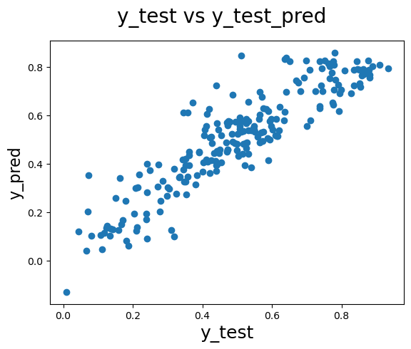

```python
fig = plt.figure()
plt.scatter(y_test, y_test_pred)
fig.suptitle('y_test vs y_test_pred', fontsize = 20)              # Plot heading
plt.xlabel('y_test', fontsize = 18)                          # X-label
plt.ylabel('y_pred', fontsize = 16)                          # y - label
```

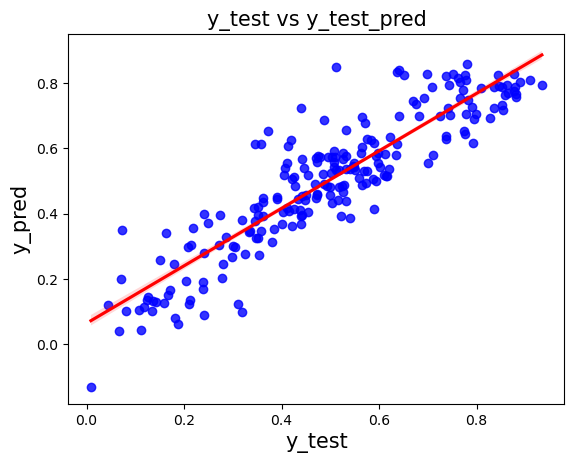

```python
# plotting a Regression plot

plt.figure()
sns.regplot(x=y_test, y=y_test_pred, ci=68, fit_reg=True,scatter_kws={"color": "blue"}, line_kws={"color": "red"})
plt.title('y_test vs y_test_pred', fontsize=15)
plt.xlabel('y_test', fontsize=15)
plt.ylabel('y_pred', fontsize=15)
plt.show()
```

```python
from sklearn.metrics import mean_squared_error,r2_score
```

```python
# Calculate mean squared error of the test set
mse_test = mean_squared_error(y_test, y_test_pred)

# Calculate RMSE
rmse_test = np.sqrt(mse_test)

print(rmse_test)
```

```
0.09449604122254024
```

```python
# R squared of training and test data
rsquared_train = r2_score(y_train, y_train_pred)
rsquared_test = r2_score(y_test, y_test_pred)

#print the squared
print('R-squared for train data:',rsquared_train)
print('R-squared for test data:',rsquared_test)
```

```
R-squared for train data: 0.8420110687421533
R-squared for test data: 0.8066246590011492
```

```python
# Coefficients of the final model
round(Final_model.params, 4)
```

```
const          0.1944
year           0.2499
holiday       -0.0794
Temperature    0.4242
spring        -0.1367
winter         0.1026
december      -0.0667
may            0.0433
november      -0.0849
september      0.0648
Tuesday       -0.0374
cloudy        -0.0831
light_rain    -0.2716
dtype: float64
```

## Regression Equation

The equation of the best fit line is given by:

`cnt` = 0.1944 + 0.2499 x `year` - 0.0794 x `holiday` + 0.4242 x `Temperature` - 0.1367 x `spring` + 0.1026 x `winter` - 0.0667 x `december` + 0.0433 x `may` - 0.0849 x `november` + 0.0648 x `september` - 0.0374 x `Tuesday` - 0.0831 x `cloudy` - 0.2716 x `light_rain`

- Analysis is been done both recursive feature elimination and Mannual elimination
- 20 features has been selected using recursive feature elimination algorithium
- The bike demand is influenced by the feature year, holiday , temperature , spring, winter, light_rain
- In final Model we have seen 84% of variability in training data and 80% of variability in testing data